# Research Question: Are soccer referees more likely to give red cards to dark skin toned players than light skin toned players?

This is an experiment conducted by a team of researchers who were interested in the variation in analysis of a dataset by different analysts. They introduced the approach of “crowdstorming a dataset.” Multiple independent analysts were invited to investigate the same hypothesis or hypotheses on the same data set in whatever manner they see as best.

They had tasked the analysts to address whether soccer referees are more likely to give red cards to dark skin toned players than light skin toned players. The available dataset provides an opportunity to identify the magnitude of the relationship among the variables.

We took the challenge to address this question through our own analysis of the data.

### **********************************************************************

## Exploring the data set

```r
setwd("/Users/Brandon/Desktop/NUS/MSBA/Statistics/DSC5103 Final Project")

#Loading the data from the csv file
data <- read.csv("CrowdstormingData.csv")
#Copying the data in a modified dataframe. This dataMod will be used for our analysis related to the original research question of analysis related to red cards
dataMod <- data

summary(data)
```

```
##               playerShort                     player
##  djibril-cisse      :   202    Juanfran          :   276
##  john-arne-riise    :   197   Djibril Cissé      :   202
##  javier-saviola     :   196   John Arne Riise    :   197
##  giorgios-karagounis:   195   Javier Saviola     :   196
##  xavi               :   188   Giorgios Karagounis:   195
##  helder-postiga     :   183    Diego             :   190
##  (Other)            :144867   (Other)            :144772
##                   club        leagueCountry         birthday
##  Fulham FC          :  2865   England:45701   10.04.1986:   345
##  VfL Wolfsburg      :  2834   France :28438   28.02.1985:   337
##  Paris Saint-Germain:  2803   Germany:39912   03.10.1978:   334
##  Bayern München     :  2792   Spain  :31977   10.03.1981:   290
##  FC Barcelona       :  2762                   11.11.1983:   286
##  Manchester City    :  2751                   04.01.1986:   282
##  (Other)            :129221                   (Other)   :144154
##      height          weight                       position
##  Min.   :161.0   Min.   : 54.00   Center Back         :22466
##  1st Qu.:177.0   1st Qu.: 71.00   Center Forward      :18687
##  Median :182.0   Median : 76.00   Defensive Midfielder:15753
##  Mean   :181.9   Mean   : 76.08   Goalkeeper          :12321
##  3rd Qu.:187.0   3rd Qu.: 81.00   Attacking Midfielder:11817
##  Max.   :203.0   Max.   :100.00   (Other)             :47258
##  NA's   :263     NA's   :2243     NA's                :17726
##      games          victories           ties            defeats
##  Min.   : 1.000   Min.   : 0.000   Min.   : 0.0000   Min.   : 0.0000
##  1st Qu.: 1.000   1st Qu.: 0.000   1st Qu.: 0.0000   1st Qu.: 0.0000
##  Median : 2.000   Median : 1.000   Median : 0.0000   Median : 1.0000
##  Mean   : 2.921   Mean   : 1.278   Mean   : 0.7082   Mean   : 0.9346
##  3rd Qu.: 3.000   3rd Qu.: 2.000   3rd Qu.: 1.0000   3rd Qu.: 1.0000
##  Max.   :47.000   Max.   :29.000   Max.   :14.0000   Max.   :18.0000
##
##      goals          yellowCards        yellowReds         redCards
##  Min.   : 0.0000   Min.   : 0.0000   Min.   :0.00000   Min.   :0.00000
##  1st Qu.: 0.0000   1st Qu.: 0.0000   1st Qu.:0.00000   1st Qu.:0.00000
##  Median : 0.0000   Median : 0.0000   Median :0.00000   Median :0.00000
##  Mean   : 0.3381   Mean   : 0.3854   Mean   :0.01138   Mean   :0.01256
##  3rd Qu.: 0.0000   3rd Qu.: 1.0000   3rd Qu.:0.00000   3rd Qu.:0.00000
##  Max.   :23.0000   Max.   :14.0000   Max.   :3.00000   Max.   :2.00000
##
```

[output cut: 9 more lines]

```
##  Min.   :  1.00   DEU    :27317   Min.   :-0.04725   Min.   :      2
##  1st Qu.:  7.00   ENGL   :26316   1st Qu.: 0.33468   1st Qu.:   1785
##  Median : 21.00   FRA    :20599   Median : 0.33663   Median :   2882
##  Mean   : 29.64   ESP    :19355   Mean   : 0.34628   Mean   :  19697
##  3rd Qu.: 44.00   ITA    : 5102   3rd Qu.: 0.36989   3rd Qu.:   7749
##  Max.   :161.00   (Other):47338   Max.   : 0.57379   Max.   :1975803
##                   NA's   :    1   NA's   :163        NA's   :163
##      seIAT            meanExp             nExp             seExp
##  Min.   :0.00000   Min.   :-1.3750   Min.   :      2   Min.   :0.00000
##  1st Qu.:0.00005   1st Qu.: 0.3361   1st Qu.:   1897   1st Qu.:0.00023
##  Median :0.00015   Median : 0.3564   Median :   3011   Median :0.00059
##  Mean   :0.00063   Mean   : 0.4520   Mean   :  20440   Mean   :0.00299
##  3rd Qu.:0.00023   3rd Qu.: 0.5883   3rd Qu.:   7974   3rd Qu.:0.00100
##  Max.   :0.28629   Max.   : 1.8000   Max.   :2029548   Max.   :1.06066
##  NA's   :163       NA's   :163       NA's   :163       NA's   :163
```

```r
dim(data)
```

```
## [1] 146028     28
```

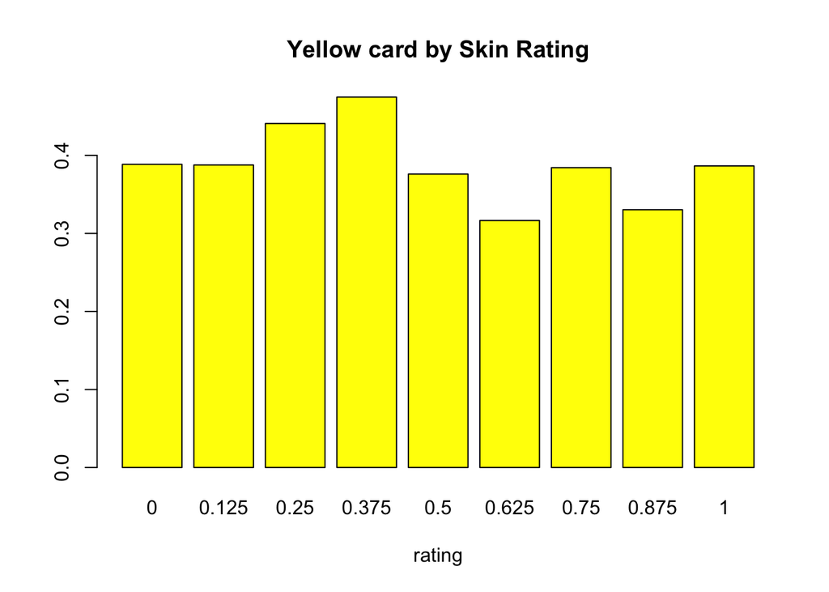

```r
data<- data[complete.cases(data[]),]
#Averaging the skin tone rating of two raters
#Calculating the total cards received for a player referee dyad
data$rating<- (data$rater1+data$rater2)/2
data$totcards<- (data$yellowCards+data$yellowReds+data$redCards)
require(ggplot2)
# Exploring the data for some initial trends by plotting the percentage of players receiving a card by different skin rating

library(plyr)
datay <- ddply(data,c("rating"),summarise,
               N=length(yellowCards),
               sum=sum(yellowCards),
               ratio=sum/N,na.rm=TRUE
               )
barplot(datay$ratio,names=datay$rating,xlab="rating",col="yellow",main="Yellow card by Skin Rating")
```

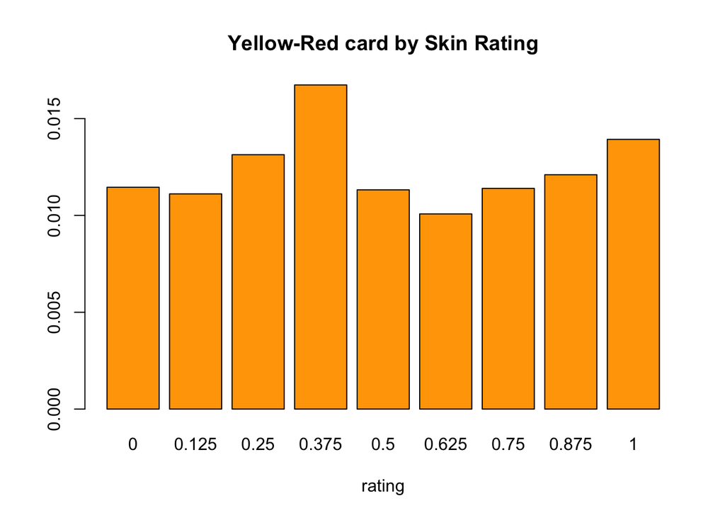

```r
datayr <- ddply(data,c("rating"),summarise,
               N=length(yellowReds),
               sum=sum(yellowReds),
               ratio=sum/N,na.rm=TRUE
               )
barplot(datayr$ratio,names=datayr$rating,xlab="rating",col="orange",main="Yellow-Red card by Skin Rating")
```

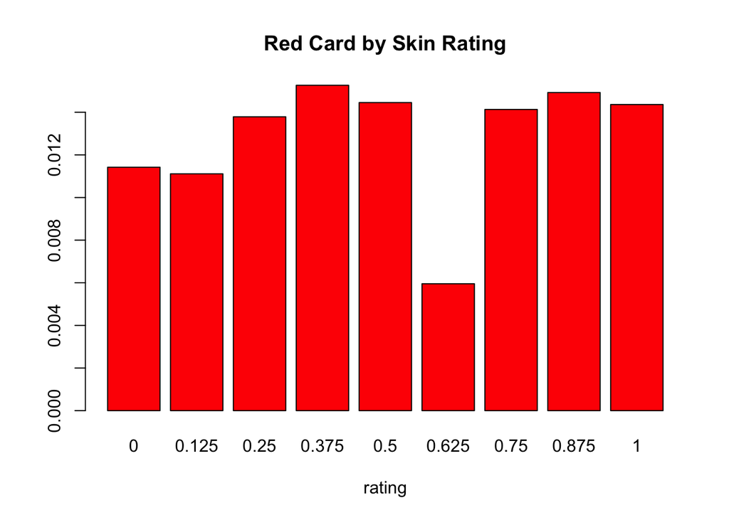

```r
datar <- ddply(data,c("rating"),summarise,
               N=length(redCards),
               sum=sum(redCards),
               ratio=sum/N,na.rm=TRUE
               )
barplot(datar$ratio,names=datar$rating,xlab="rating",col="red",main="Red Card by Skin Rating")
```

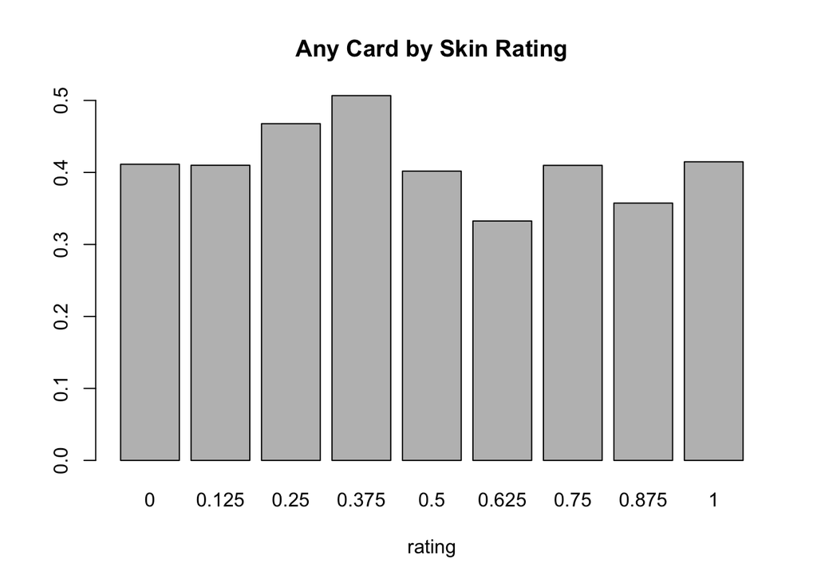

```r
dataall <- ddply(data,c("rating"),summarise,
               N=length(totcards),
               sum=sum(totcards),
               ratio=sum/N,na.rm=TRUE
               )
barplot(dataall$ratio,names=dataall$rating,xlab="rating",col="grey",main="Any Card by Skin Rating")
```

All the above 4 graphs suggest that there is no major difference between the % of red card received based on the skin colour. This will require more deep dive study of the data to find any trends that may be missed out in a very high level analysis.

```r
# Dividing the Quartiles based on the meanIAT score of the countries to study if there is any relationship between giving red cards to colored players and the meanIAP score

data$Quartile<-with(data,cut(meanIAT,breaks=quantile(meanIAT,probs=seq(0,1,by=0.25)),include.lowest=TRUE))

table(data$Quartile)
```

```
##
## [-0.0473,0.335]   (0.335,0.337]    (0.337,0.37]    (0.37,0.574]
##           35008           25806           37063           17580
```

```r
summary(data$Quartile)
```

```
## [-0.0473,0.335]   (0.335,0.337]    (0.337,0.37]    (0.37,0.574]
##           35008           25806           37063           17580
```

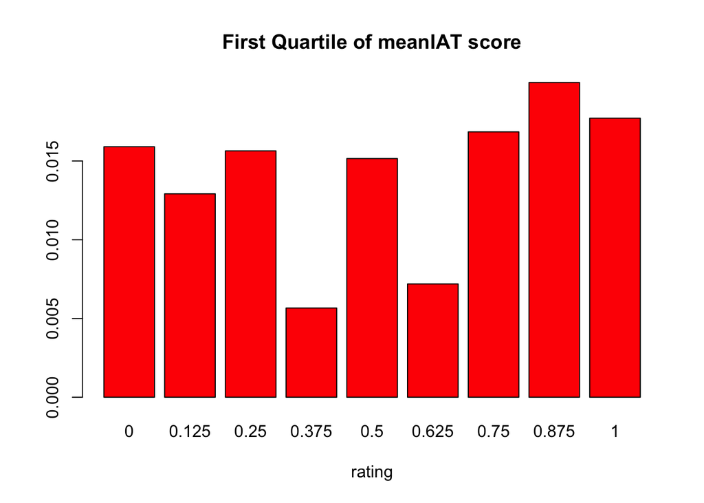

```r
Quart1<-subset(data,meanIAT<=.335)
Quart2<-subset(data,meanIAT>.335 & meanIAT<=.337)
Quart3<-subset(data,meanIAT>.337 & meanIAT<=.37)
Quart4<-subset(data,meanIAT>.37)
# Finding Percentage of Players receiving Red Cards by Skin Rating in Different Quartiles of meanIAT score

dataQ1r <- ddply(Quart1,c("rating"),summarise,
               N=length(redCards),
               sum=sum(redCards),
               ratio=sum/N,na.rm=TRUE
               )
barplot(dataQ1r$ratio,names=dataQ1r$rating,xlab="rating",col="red",main="First Quartile of meanIAT score")
```

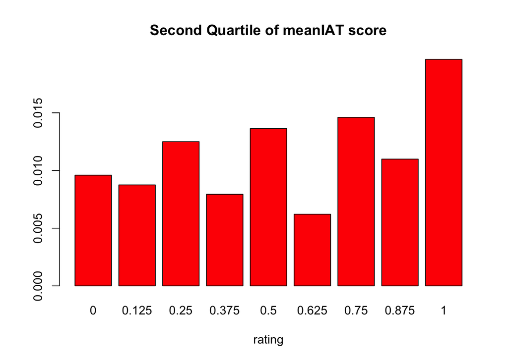

```r
dataQ2r <- ddply(Quart2,c("rating"),summarise,
               N=length(redCards),
               sum=sum(redCards),
               ratio=sum/N,na.rm=TRUE
               )
barplot(dataQ2r$ratio,names=dataQ2r$rating,xlab="rating",col="red",main="Second Quartile of meanIAT score")
```

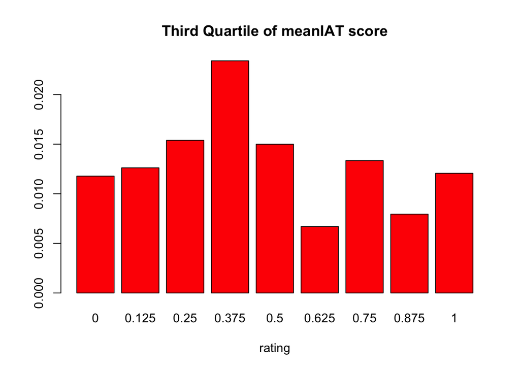

```r
dataQ3r <- ddply(Quart3,c("rating"),summarise,
               N=length(redCards),
               sum=sum(redCards),
               ratio=sum/N,na.rm=TRUE
               )
barplot(dataQ3r$ratio,names=dataQ3r$rating,xlab="rating",col="red",main="Third Quartile of meanIAT score")
```

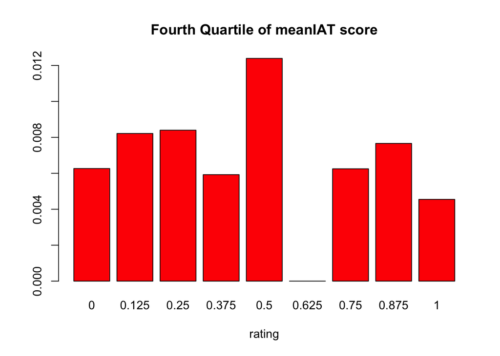

```r
dataQ4r <- ddply(Quart4,c("rating"),summarise,
               N=length(redCards),
               sum=sum(redCards),
               ratio=sum/N,na.rm=TRUE
               )
barplot(dataQ4r$ratio,names=dataQ4r$rating,xlab="rating",col="red",main="Fourth Quartile of meanIAT score")
```

```r
rm(Quart1)
rm(Quart2)
rm(Quart3)
rm(Quart4)
```

### **********************************************************************

## Research Question: Are soccer referees more likely to give red cards to dark skin toned players than light skin toned players?*

## Data Manipulation

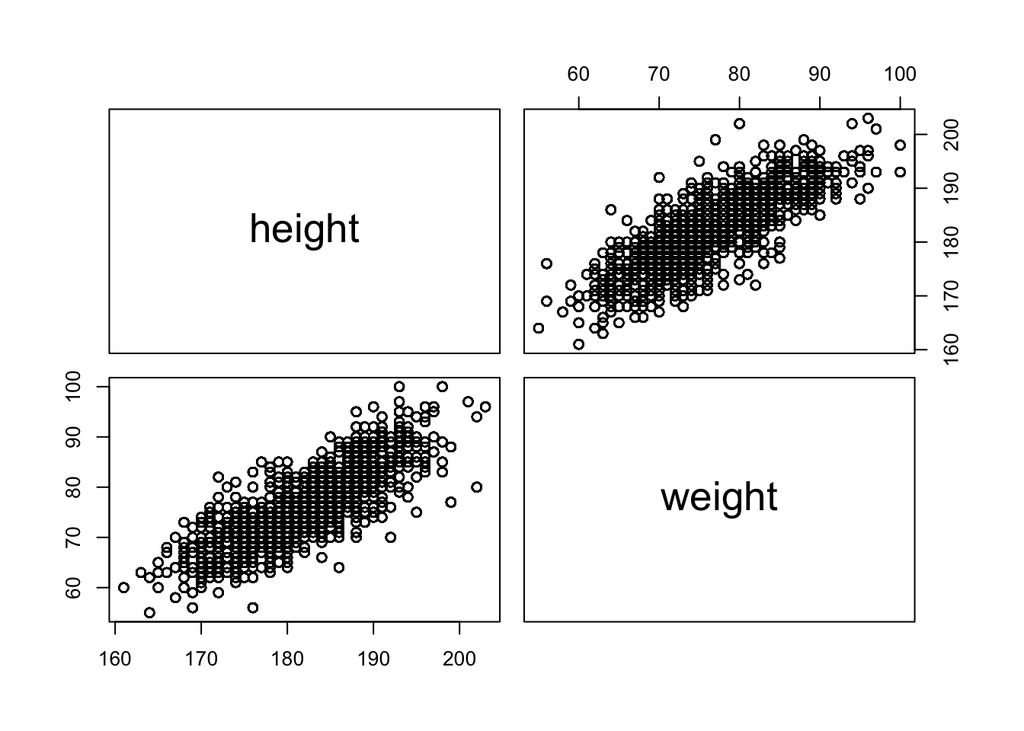

```r
#Removing following columns as they don't seem relevant for our analysis related to Red Cards

# "player short" "player" "club" "league country" "birthday" "yellow cards" "yellow reds" "photo id"
#"refNum" "ref Country" "Alpha 3" "nIAT" "seIAT" "nExp" "seExp"

dataMod<- dataMod[-c(1,2,3,4,5,14,15,17,20,21,22,24,25,27,28)]
dataMod<- dataMod[complete.cases(dataMod[]),]

#Averaging the skin tone rating of two raters
dataMod$rating<- (dataMod$rater1+dataMod$rater2)/2

#checking correlation
#height is correlated to weight
pairs(height~weight, data=dataMod)
```

```r
#vector of columns to be removed while doing analysis
# - height - games - redCards - rater1 - rater2 - meanIAT  - meanExp - BinReds
remcol <- c(1,4,9,10,11,12,13,15)
```

The data has # of games and # of red cards a player was given by that refree. However this is the aggregated data as it doesn’t differentiate between following two cases If a player-refree played 10 games and player was given red card 2 times If a player-refree played 5x games and player was given red card 2 times Case 2 is a more strong predictor of the refree giving red card to that player So we disaggregate our data and make red cards a binary response variable

```r
#Manipulating RedCards column
#Calculating non zero averages for redcards per game and taking the top 91%
#Adding a Binary Column for Red Cards if the average is above 0.066
# ModRed <- with(subset(dataMod, dataMod$redCards > 0) , redCards/games)
# ModRed <- as.data.frame(ModRed)
# nrow(subset(ModRed, ModRed > 0.066))
# 1326/1455

dataMod$BinReds <- as.factor(ifelse(dataMod$redCards/dataMod$games > 0.066,1,0))
summary(dataMod)
```

```
##      height          weight                       position
##  Min.   :161.0   Min.   : 55.00   Center Back         :20513
##  1st Qu.:178.0   1st Qu.: 72.00   Center Forward      :16591
##  Median :183.0   Median : 76.00   Defensive Midfielder:13906
##  Mean   :182.2   Mean   : 76.52   Goalkeeper          :11004
##  3rd Qu.:187.0   3rd Qu.: 81.00   Attacking Midfielder:10757
##  Max.   :203.0   Max.   :100.00   Left Fullback       : 8976
##                                   (Other)             :33710
##      games          victories           ties            defeats
##  Min.   : 1.000   Min.   : 0.000   Min.   : 0.0000   Min.   : 0.0000
##  1st Qu.: 1.000   1st Qu.: 0.000   1st Qu.: 0.0000   1st Qu.: 0.0000
##  Median : 1.000   Median : 1.000   Median : 0.0000   Median : 1.0000
##  Mean   : 3.034   Mean   : 1.372   Mean   : 0.7211   Mean   : 0.9411
##  3rd Qu.: 3.000   3rd Qu.: 2.000   3rd Qu.: 1.0000   3rd Qu.: 1.0000
##  Max.   :47.000   Max.   :29.000   Max.   :14.0000   Max.   :18.0000
##
##      goals            redCards          rater1           rater2
##  Min.   : 0.0000   Min.   :0.0000   Min.   :0.0000   Min.   :0.0000
##  1st Qu.: 0.0000   1st Qu.:0.0000   1st Qu.:0.0000   1st Qu.:0.0000
##  Median : 0.0000   Median :0.0000   Median :0.2500   Median :0.2500
##  Mean   : 0.3604   Mean   :0.0128   Mean   :0.2619   Mean   :0.3008
##  3rd Qu.: 0.0000   3rd Qu.:0.0000   3rd Qu.:0.2500   3rd Qu.:0.5000
##  Max.   :23.0000   Max.   :2.0000   Max.   :1.0000   Max.   :1.0000
##
##     meanIAT            meanExp            rating       BinReds
##  Min.   :-0.04725   Min.   :-1.3750   Min.   :0.0000   0:114131
##  1st Qu.: 0.33468   1st Qu.: 0.3360   1st Qu.:0.0000   1:  1326
##  Median : 0.33663   Median : 0.3564   Median :0.2500
##  Mean   : 0.34856   Mean   : 0.4662   Mean   :0.2814
##  3rd Qu.: 0.36989   3rd Qu.: 0.5883   3rd Qu.:0.3750
##  Max.   : 0.57379   Max.   : 1.8000   Max.   :1.0000
##
```

```r
#Creating training and validation data set.
#Our total data is approx 145K+ and # of red cards are just 1.4K so we have to split the training and testing data in a way that control the distribution of red cards accordingly.
#We are using caret package to control for BinReds. The logic is that if we split the training and test data in 70:30 then red cards are also split in 70:30
library("caret")
set.seed(3456)
trainIndex <- createDataPartition(dataMod$BinReds, p = .7, list = FALSE, times = 1)
x.train <- dataMod[trainIndex,-remcol]
y.train <- dataMod[trainIndex,15]

x.test <- dataMod[-trainIndex, -remcol]
y.test<- dataMod[-trainIndex, 15]
```

## Data Analysis

### **********************************************************************

### 1.Logistical Regression

### **********************************************************************

```r
library("MASS")
glm.lr<- glm(y.train ~ . , data=x.train,family=binomial() )
reg.model<- stepAIC(glm.lr, direction="both")
```

```
## Start:  AIC=9756
## y.train ~ weight + position + victories + ties + defeats + goals +
##     rating
##
##             Df Deviance    AIC
## - goals      1   9720.0 9754.0
## - weight     1   9720.8 9754.8
## - victories  1   9721.9 9755.9
## <none>           9720.0 9756.0
## - rating     1   9733.1 9767.1
## - ties       1   9737.8 9771.8
## - position  11   9799.8 9813.8
## - defeats    1   9826.8 9860.8
##
## Step:  AIC=9754.03
## y.train ~ weight + position + victories + ties + defeats + rating
##
##             Df Deviance    AIC
## - weight     1   9720.8 9752.8
## <none>           9720.0 9754.0
## - victories  1   9722.3 9754.3
## + goals      1   9720.0 9756.0
## - rating     1   9733.1 9765.1
## - ties       1   9737.9 9769.9
## - position  11   9804.0 9816.0
## - defeats    1   9827.5 9859.5
##
## Step:  AIC=9752.85
## y.train ~ position + victories + ties + defeats + rating
##
##             Df Deviance    AIC
## <none>           9720.8 9752.8
## - victories  1   9723.1 9753.1
## + weight     1   9720.0 9754.0
## + goals      1   9720.8 9754.8
## - rating     1   9734.1 9764.1
## - ties       1   9738.9 9768.9
## - position  11   9809.2 9819.2
## - defeats    1   9828.0 9858.0
```

```r
summary(reg.model)
```

```
##
## Call:
## glm(formula = y.train ~ position + victories + ties + defeats +
##     rating, family = binomial(), data = x.train)
##
## Deviance Residuals:
##     Min       1Q   Median       3Q      Max
## -1.1171  -0.1583  -0.1324  -0.1182   3.2773
##
## Coefficients:
##                              Estimate Std. Error z value Pr(>|z|)
## (Intercept)                  -5.38825    0.14104 -38.203  < 2e-16 ***
## positionCenter Back           0.88960    0.15062   5.906 3.50e-09 ***
## positionCenter Forward        0.12530    0.17016   0.736 0.461495
## positionCenter Midfielder     0.04190    0.23832   0.176 0.860438
## positionDefensive Midfielder  0.39186    0.16753   2.339 0.019333 *
## positionGoalkeeper            0.42672    0.17342   2.461 0.013870 *
## positionLeft Fullback         0.30787    0.18511   1.663 0.096273 .
## positionLeft Midfielder       0.31746    0.20155   1.575 0.115234
## positionLeft Winger          -0.17058    0.25960  -0.657 0.511134
## positionRight Fullback        0.48349    0.17975   2.690 0.007149 **
## positionRight Midfielder      0.06261    0.23735   0.264 0.791948
## positionRight Winger          0.34049    0.21185   1.607 0.108004
## victories                     0.02248    0.01461   1.539 0.123912
## ties                          0.11183    0.02559   4.370 1.24e-05 ***
## defeats                       0.19970    0.01810  11.033  < 2e-16 ***
## rating                        0.41344    0.11162   3.704 0.000212 ***
## ---
## Signif. codes:  0 '***' 0.001 '**' 0.01 '*' 0.05 '.' 0.1 ' ' 1
##
## (Dispersion parameter for binomial family taken to be 1)
##
##     Null deviance: 10144.9  on 80820  degrees of freedom
## Residual deviance:  9720.8  on 80805  degrees of freedom
## AIC: 9752.8
##
## Number of Fisher Scoring iterations: 7
```

```r
RedCard.Pred<-predict (reg.model, newdata = x.test,type="response")
```

*So as per simplistic logistic model “ratings” is a highly significant variable in predicting the true Red Cards.* *We also see that higher the value of ratings higher the probability of Red Cards.* *So from this model we see that there is certainly a color bias and probability of a darker skin player to receive red card is more.*

```r
#Evaluate Performance characteristics for this model
library("ROCR")
logistic.pred<- prediction(RedCard.Pred, y.test)
# misclassification rate
logistic.err <- performance(logistic.pred, measure = "err")
#AUC
logistic.AUC <- as.numeric(performance(logistic.pred, "auc")@y.values)
logistic.AUC
```

```
## [1] 0.7051668
```

### **********************************************************************

### 2.Random Forrest Tree

### **********************************************************************

```r
library("randomForest")
# tune random forest (mtry) by tuneRF (highly variable)
#This code has been commented to generate the html file as it was taking long time.
#Results of execution have been pasted here

# tuneRF(x=x.train, y=y.train, mtryStart=3, ntreeTry=501, stepFactor=1.5)

#Results
#       mtry   OOBError
# 2.OOB    2 0.01149454
# 3.OOB    3 0.01184098
# 4.OOB    4 0.01241014

# fit a random forest model
set.seed(12)
RedC.rf <- randomForest(y.train ~ . , data=x.train, mtry=2, ntree=501)
RedC.rf
```

```
##
## Call:
##  randomForest(formula = y.train ~ ., data = x.train, mtry = 2,      ntree = 501)
##                Type of random forest: classification
##                      Number of trees: 501
## No. of variables tried at each split: 2
##
##         OOB estimate of  error rate: 1.15%
## Confusion matrix:
##       0 1  class.error
## 0 79889 3 3.755069e-05
## 1   929 0 1.000000e+00
```

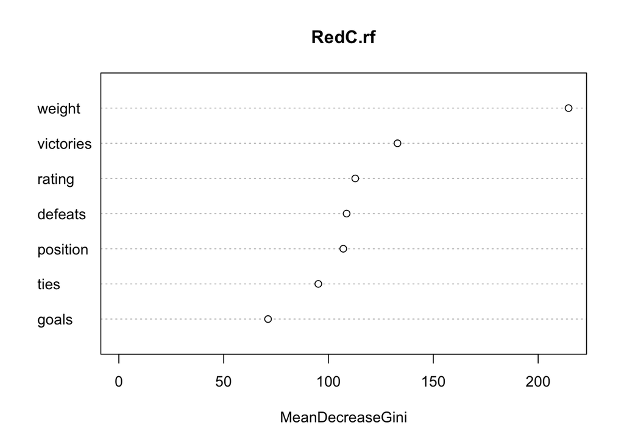

```r
#plot(RedC.rf)

# variable importance
varImpPlot(RedC.rf)
```

*From variable importance flag we see that weight, victories and ratings are the 3 most important variables for predicting the Red Cards.*

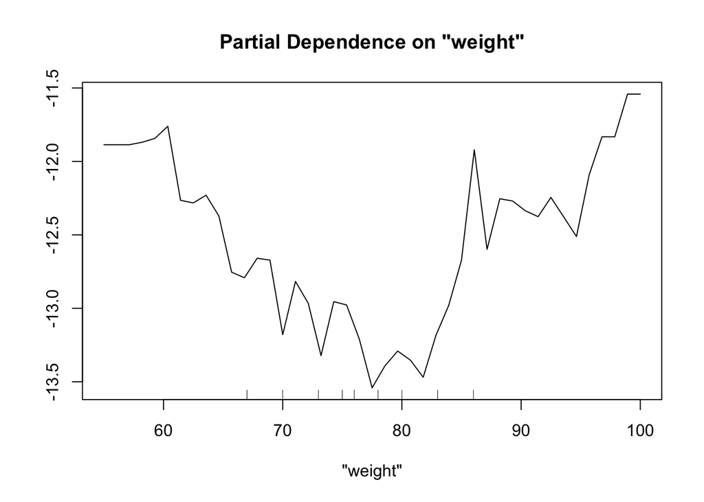

```r
# partial plot in RF
partialPlot(RedC.rf, x.train, x.var="weight", which.class="1")
```

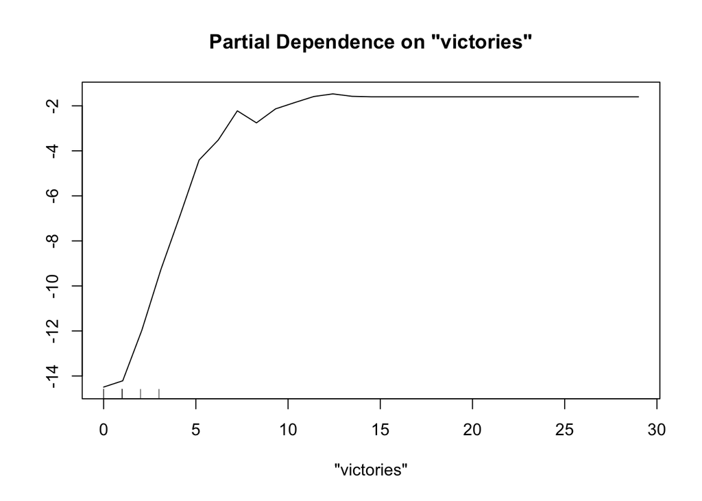

```r
partialPlot(RedC.rf, x.train, x.var="victories", which.class="1")
```

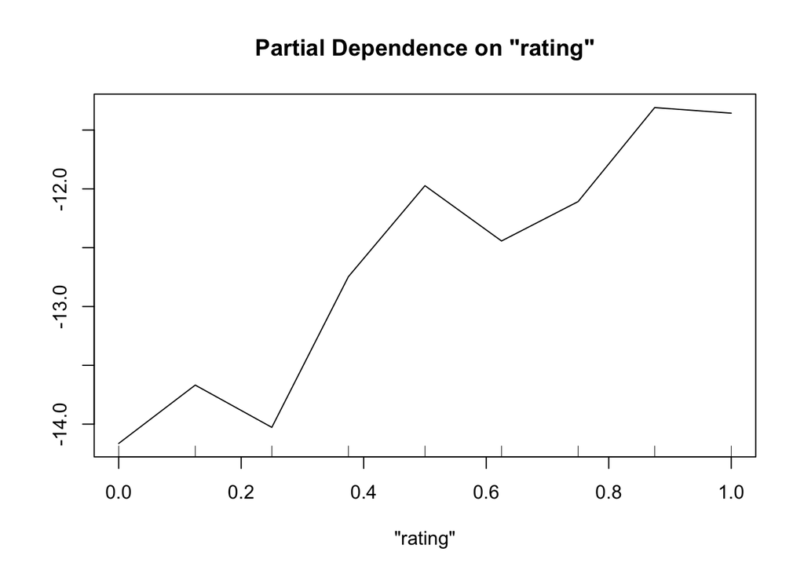

```r
partialPlot(RedC.rf, x.train, x.var="rating", which.class="1")
```

*For weights lesser than 75 Kgs and more than 82 Kgs the probability of getting a red card increases* *With increasing victories the probability of getting a red card increases and levels around 12 victories* *Probability of a player getting a red card increases for darker color players*

```r
#Evaluate Performance characteristics for this model
prob.rf <- predict(RedC.rf, newdata=x.test, type="prob")[, 2]
# misclassification rate
prediction.rf <- prediction(prob.rf, y.test)
#AUC
rf.AUC <- as.numeric(performance(prediction.rf, "auc")@y.values)
rf.AUC
```

```
## [1] 0.6787781
```

```r
# library("gbm")
#
# # convert Class into a 0-1 numerical variable for GBM
# y <- as.numeric(y.train) - 1
#
# # Tuning the gbm: The code has been commented as it was taking lot of time to run.
# # Results from the execution of the code are pasted here for reference
# # set.seed(321)
# # n.step <- 50
# # ds <- c(1, 2, 4)
# # lambdas <- c(0.001, 0.0005, 0.0003)
# # d.size <- length(ds)
# # l.size <- length(lambdas)
# #
# # tune.out <- data.frame()
# # for (i in 1:d.size) {
# #         for (j in 1:l.size) {
# #                 d <- ds[i]
# #                 lambda <- lambdas[j]
# #                 for (n in (1:10) * n.step / (lambda * sqrt(d))) {
# #                         set.seed(321)
# #                         gbm.mod <-  gbm(y ~ ., data=x.train, distribution="bernoulli", n.trees=n, interaction.depth=d, shrinkage=lambda, cv.folds=10)
# #                         n.opt <- gbm.perf(gbm.mod, method="cv")
# #                         cat("n =", n, " n.opt =", n.opt, "\n")
# #                         if (n.opt / n < 0.95) break
# #                 }
# #                 cv.err <- gbm.mod$cv.error[n.opt]
# #                 out <- data.frame(d=d, lambda=lambda, n=n, n.opt=n.opt, cv.err=cv.err)
# #                 print(out)
# #                 tune.out <- rbind(tune.out, out)
# #         }
# # }
#
# #Best Model chosen from above
# set.seed(321)
# RedC.gbm <- gbm(y.train ~ ., data=x.train, distribution="bernoulli", n.trees=25000, interaction.depth=2, shrinkage=0.0003)
# RedC.gbm
# # variable importance
# summary(RedC.gbm)
#
# # partial plot in gbm
# plot(RedC.gbm, i="weight", type="response")
# plot(RedC.gbm, i="victories", type="response")
# plot(RedC.gbm, i="rating", type="response")
#
# #Evaluate Performance characteristics for this model
# prob.gbm <- predict(RedC.gbm, newdata=x.test, n.trees=50000, type="response")
# #Misclassification Rate
# prediction.gbm <- prediction(prob.gbm, y.test)
# #AUC
# AUC.gbm <- as.numeric(performance(prediction.gbm, "auc")@y.values)
# AUC.gbm
```

```r
rm(dataMod)
rm(x.train)
rm(y.train)
rm(x.test)
rm(y.test)
```

# Soccer referees are more likely to give red cards to players with darker skin tone than light skin toned players.

## Extension to Research Question

### 1)Are dark skin toned players more likely to receive a card (yellow or red) from soccer referees than light skin toned players?

### 2) What other factors that may have caused a player to receive a card from soccer referees?

```r
#Consider yellowCards, yellowReds and redCards as a result
data$card_result=ifelse(data$yellowCards+data$yellowReds+data$redCards>0,1,0)
table(data$card_result)
```

```
##
##     0     1
## 82380 33077
```

```r
df <- data.frame(card_result = data$card_result, rating = data$rating, weight = data$weight, height = data$height, position = data$position)
summary(df)
```

```
##   card_result         rating           weight           height
##  Min.   :0.0000   Min.   :0.0000   Min.   : 55.00   Min.   :161.0
##  1st Qu.:0.0000   1st Qu.:0.0000   1st Qu.: 72.00   1st Qu.:178.0
##  Median :0.0000   Median :0.2500   Median : 76.00   Median :183.0
##  Mean   :0.2865   Mean   :0.2814   Mean   : 76.52   Mean   :182.2
##  3rd Qu.:1.0000   3rd Qu.:0.3750   3rd Qu.: 81.00   3rd Qu.:187.0
##  Max.   :1.0000   Max.   :1.0000   Max.   :100.00   Max.   :203.0
##
##                  position
##  Center Back         :20513
##  Center Forward      :16591
##  Defensive Midfielder:13906
##  Goalkeeper          :11004
##  Attacking Midfielder:10757
##  Left Fullback       : 8976
##  (Other)             :33710
```

```r
str(df)
```

```
## 'data.frame':    115457 obs. of  5 variables:
##  $ card_result: num  0 1 0 0 0 0 0 1 0 0 ...
##  $ rating     : num  0.375 0.75 0.125 0.125 1 0.25 0 0 0.5 0 ...
##  $ weight     : int  72 82 71 80 68 80 70 74 74 80 ...
##  $ height     : int  177 179 182 187 180 193 180 177 181 187 ...
##  $ position   : Factor w/ 12 levels "Attacking Midfielder",..: 1 12 2 7 5 6 10 10 9 2 ...
```

```r
# separate training and test
library("caret")
set.seed(3456)
train.index <- createDataPartition(data$card_result, p = .7, list = FALSE, times = 1)
#str(train.index)
#train.index <- sample(1:nrow(df), nrow(df)/2)
df.train <- df[train.index, ]
df.test <- df[-train.index, ]
```

### **********************************************************************

### **********************************************************************

### effect of skin colour on card result

```r
library("MASS")
glm1<- glm(card_result ~ rating, data=df.train,family=binomial() )
summary(glm1)
```

```
##
## Call:
## glm(formula = card_result ~ rating, family = binomial(), data = df.train)
##
## Deviance Residuals:
##     Min       1Q   Median       3Q      Max
## -0.8298  -0.8218  -0.8204   1.5741   1.5845
##
## Coefficients:
##             Estimate Std. Error z value Pr(>|z|)
## (Intercept) -0.91983    0.01090 -84.382   <2e-16 ***
## rating       0.03073    0.02703   1.137    0.256
## ---
## Signif. codes:  0 '***' 0.001 '**' 0.01 '*' 0.05 '.' 0.1 ' ' 1
##
## (Dispersion parameter for binomial family taken to be 1)
##
##     Null deviance: 96859  on 80819  degrees of freedom
## Residual deviance: 96858  on 80818  degrees of freedom
## AIC: 96862
##
## Number of Fisher Scoring iterations: 4
```

```r
#card_result.Pred <-predict (glm1, newdata = df.train ,type="response")
card_result.Pred <-predict (glm1, newdata = df.test ,type="response")

library("ROCR")
glm1.pred<- prediction(card_result.Pred, df.test$card_result)
glm1.AUC <- as.numeric(performance(glm1.pred, "auc")@y.values)
glm1.AUC
```

```
## [1] 0.5114924
```

### **********************************************************************

### effect of physical attribute on card result

```r
glm2 <- glm(card_result ~ rating + weight + height, family=binomial, data=df.train)
summary(glm2)
```

```
##
## Call:
## glm(formula = card_result ~ rating + weight + height, family = binomial,
##     data = df.train)
##
## Deviance Residuals:
##     Min       1Q   Median       3Q      Max
## -0.9282  -0.8323  -0.8014   1.5260   1.7275
##
## Coefficients:
##              Estimate Std. Error z value Pr(>|z|)
## (Intercept)  1.874948   0.246722   7.599 2.97e-14 ***
## rating       0.006231   0.027178   0.229   0.8187
## weight       0.003957   0.001774   2.231   0.0257 *
## height      -0.016975   0.001864  -9.108  < 2e-16 ***
## ---
## Signif. codes:  0 '***' 0.001 '**' 0.01 '*' 0.05 '.' 0.1 ' ' 1
##
## (Dispersion parameter for binomial family taken to be 1)
##
##     Null deviance: 96859  on 80819  degrees of freedom
## Residual deviance: 96707  on 80816  degrees of freedom
## AIC: 96715
##
## Number of Fisher Scoring iterations: 4
```

```r
card_result.Pred<-predict (glm2, newdata = df.test, type="response")

glm2.pred<- prediction(card_result.Pred, df.test$card_result)
glm2.AUC <- as.numeric(performance(glm2.pred, "auc")@y.values)
glm2.AUC
```

```
## [1] 0.5276191
```

### **********************************************************************

### effect of position on card result

```r
summary(data$position)
```

```
## Attacking Midfielder          Center Back       Center Forward
##                10757                20513                16591
##    Center Midfielder Defensive Midfielder           Goalkeeper
##                 4827                13906                11004
##        Left Fullback      Left Midfielder          Left Winger
##                 8976                 6208                 4498
##       Right Fullback     Right Midfielder         Right Winger
##                 8410                 4629                 5138
```

```r
glm3 <- glm(card_result ~ position, family=binomial, data=df.train)
summary(glm3)
```

```
##
## Call:
## glm(formula = card_result ~ position, family = binomial, data = df.train)
##
## Deviance Residuals:
##     Min       1Q   Median       3Q      Max
## -0.9625  -0.8779  -0.7447   1.4088   2.0394
##
## Coefficients:
##                              Estimate Std. Error z value Pr(>|z|)
## (Intercept)                  -0.96101    0.02580 -37.249  < 2e-16 ***
## positionCenter Back           0.28741    0.03125   9.197  < 2e-16 ***
## positionCenter Forward       -0.17987    0.03369  -5.339 9.37e-08 ***
## positionCenter Midfielder     0.20636    0.04525   4.561 5.10e-06 ***
## positionDefensive Midfielder  0.43184    0.03326  12.984  < 2e-16 ***
## positionGoalkeeper           -0.98504    0.04294 -22.940  < 2e-16 ***
## positionLeft Fullback         0.13865    0.03756   3.692 0.000223 ***
## positionLeft Midfielder       0.09663    0.04201   2.300 0.021442 *
## positionLeft Winger          -0.04648    0.04782  -0.972 0.331130
## positionRight Fullback        0.25682    0.03792   6.774 1.26e-11 ***
## positionRight Midfielder      0.05209    0.04670   1.116 0.264610
## positionRight Winger         -0.19252    0.04682  -4.112 3.92e-05 ***
## ---
## Signif. codes:  0 '***' 0.001 '**' 0.01 '*' 0.05 '.' 0.1 ' ' 1
##
## (Dispersion parameter for binomial family taken to be 1)
##
##     Null deviance: 96859  on 80819  degrees of freedom
## Residual deviance: 94948  on 80808  degrees of freedom
## AIC: 94972
##
## Number of Fisher Scoring iterations: 4
```

```r
card_result.Pred<-predict (glm3, newdata = df.test,type="response")

glm3.pred<- prediction(card_result.Pred, df.test$card_result)
glm3.AUC <- as.numeric(performance(glm3.pred, "auc")@y.values)
glm3.AUC
```

```
## [1] 0.591534
```

### **********************************************************************

### effect of physical attribute and position on card result

```r
glm.all <- glm(card_result ~ rating + weight + height + position, family=binomial, data=df.train)
glm4 <- stepAIC(glm.all, scope=list(upper = glm.all, lower = glm1))
```

```
## Start:  AIC=94900.85
## card_result ~ rating + weight + height + position
##
##            Df Deviance   AIC
## <none>           94871 94901
## - weight    1    94920 94948
## - height    1    94944 94972
## - position 11    96707 96715
```

```r
summary(glm4)
```

```
##
## Call:
## glm(formula = card_result ~ rating + weight + height + position,
##     family = binomial, data = df.train)
##
## Deviance Residuals:
##     Min       1Q   Median       3Q      Max
## -1.0398  -0.8759  -0.7687   1.4281   2.1292
##
## Coefficients:
##                               Estimate Std. Error z value Pr(>|z|)
## (Intercept)                   1.171138   0.283203   4.135 3.54e-05 ***
## rating                       -0.043660   0.027869  -1.567 0.117205
## weight                        0.012883   0.001833   7.027 2.10e-12 ***
## height                       -0.017198   0.002012  -8.546  < 2e-16 ***
## positionCenter Back           0.345145   0.034500  10.004  < 2e-16 ***
## positionCenter Forward       -0.146215   0.035099  -4.166 3.10e-05 ***
## positionCenter Midfielder     0.222773   0.045508   4.895 9.82e-07 ***
## positionDefensive Midfielder  0.463301   0.033923  13.657  < 2e-16 ***
## positionGoalkeeper           -0.935707   0.046901 -19.951  < 2e-16 ***
## positionLeft Fullback         0.143121   0.037822   3.784 0.000154 ***
## positionLeft Midfielder       0.105443   0.042106   2.504 0.012271 *
## positionLeft Winger          -0.033997   0.048078  -0.707 0.479490
## positionRight Fullback        0.271738   0.038177   7.118 1.10e-12 ***
## positionRight Midfielder      0.049499   0.046763   1.059 0.289822
## positionRight Winger         -0.195271   0.047247  -4.133 3.58e-05 ***
## ---
## Signif. codes:  0 '***' 0.001 '**' 0.01 '*' 0.05 '.' 0.1 ' ' 1
##
## (Dispersion parameter for binomial family taken to be 1)
##
##     Null deviance: 96859  on 80819  degrees of freedom
## Residual deviance: 94871  on 80805  degrees of freedom
## AIC: 94901
##
## Number of Fisher Scoring iterations: 4
```

```r
card_result.Pred<-predict (glm4, newdata = df.test, type="response")

glm4.pred<- prediction(card_result.Pred, df.test$card_result)
glm4.AUC <- as.numeric(performance(glm4.pred, "auc")@y.values)
glm4.AUC
```

```
## [1] 0.5943617
```

### **********************************************************************

### ROCR

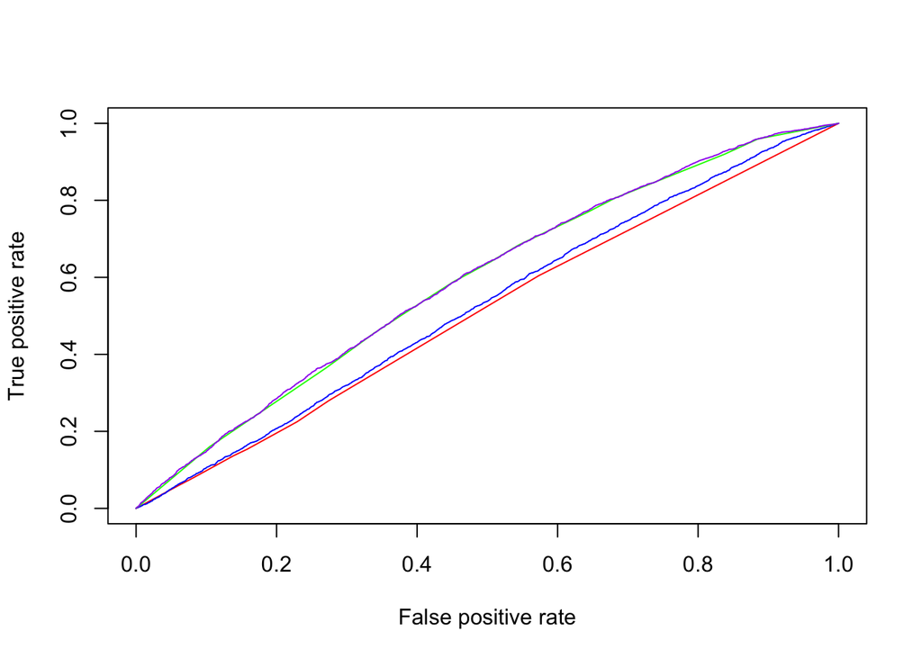

```r
glm1.perf <- performance(glm1.pred, "tpr", "fpr")
glm2.perf <- performance(glm2.pred, "tpr", "fpr")
glm3.perf <- performance(glm3.pred, "tpr", "fpr")
glm4.perf <- performance(glm4.pred, "tpr", "fpr")

plot(glm1.perf, col="red")
plot(glm2.perf, col="blue", add=TRUE)
plot(glm3.perf, col="green", add=TRUE)
plot(glm4.perf, col="purple", add=TRUE)
```

```r
set.seed(111)
K <- 10
folds <- sample(1:K, nrow(df.train), replace=TRUE)
table(folds)
```

```
## folds
##    1    2    3    4    5    6    7    8    9   10
## 8205 8118 8080 8044 8081 7975 7968 8179 8110 8060
```

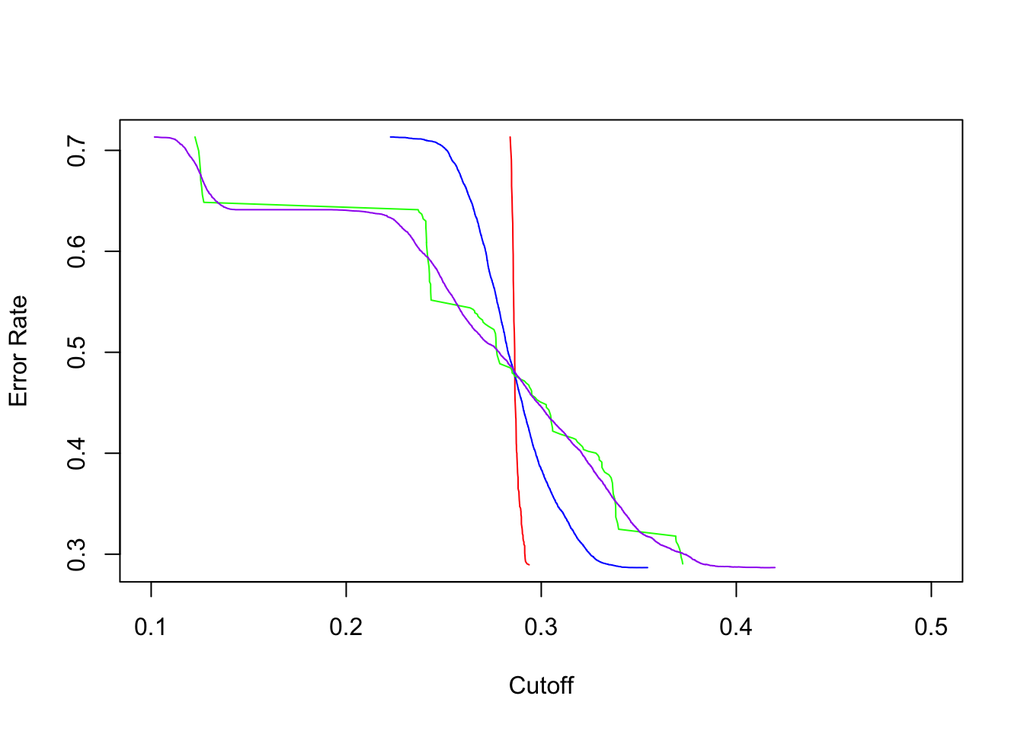

```r
for (k in 1:K) {
  cv.glm1 <- glm(card_result ~ rating, family=binomial(), data=df.train[folds != k, ])
  cv.glm2 <- glm(card_result ~ rating + weight + height, family=binomial, data=df.train[folds != k, ])
  cv.glm3 <- glm(card_result ~ position, family=binomial, data=df.train[folds != k, ])
  cv.glm4 <- glm(card_result ~ rating + weight + height + position, family=binomial,data=df.train[folds != k, ])
  df.train[folds == k, "glm1.prob"] <- predict(cv.glm1, newdata=df.train[folds == k, ], type="response")
  df.train[folds == k, "glm2.prob"] <- predict(cv.glm2, newdata=df.train[folds == k, ], type="response")
  df.train[folds == k, "glm3.prob"] <- predict(cv.glm3, newdata=df.train[folds == k, ], type="response")
  df.train[folds == k, "glm4.prob"] <- predict(cv.glm4, newdata=df.train[folds == k, ], type="response")
}

pred1 <- prediction(df.train$glm1.prob, df.train$card_result)
pred2 <- prediction(df.train$glm2.prob, df.train$card_result)
pred3 <- prediction(df.train$glm3.prob, df.train$card_result)
pred4 <- prediction(df.train$glm4.prob, df.train$card_result)

perf1 <- performance(pred1, measure="err")
perf2 <- performance(pred2, measure="err")
perf3 <- performance(pred3, measure="err")
perf4 <- performance(pred4, measure="err")

plot(perf1, col="red", xlim=c(0.1,0.5))
plot(perf2, col="blue", add=TRUE)
plot(perf3, col="green", add=TRUE)
plot(perf4, col="purple", add=TRUE)
```

### **********************************************************************

### **********************************************************************

```r
library("randomForest")
df.train$card_result<-as.factor(df.train$card_result)

#This code has been commented to generate the html file as it was taking long time.
# tuneRF(x=df.train[, -9], y=df.train[, 9], mtryStart=2, ntreeTry=500, stepFactor=1.5)
# head(df.train)
#as tuneRF is giving very unstable output, we further tried to tune manually.
#tuning manually
# evaluating optimal number of predictors *mtry*
# miscal.rfs <- rep(0, 8)
# for(m in 1:8) {
#   set.seed(12)
#   rf <- randomForest(card_result ~ ., data=df.train[,-c(6,7,8,9)], mtry=8, ntree=500, importance=TRUE)
#   miscal.rfs[m] <- rf$err.rate[m,"OOB"]
# }
#
# plot(1:8, miscal.rfs, type="b", xlab="mtry", ylab="OOB Error")
#
# optm.rf<- which.min(miscal.rfs)

optm.rf <- 3

#optimal model
soccer.rf<- randomForest(card_result ~ ., data=df.train[,-c(6,7,8,9)], mtry=optm.rf, ntree=501, importance=TRUE)
importance(soccer.rf)
```

```
##                  0         1 MeanDecreaseAccuracy MeanDecreaseGini
## rating   132.76398 -17.85869            168.16448         446.9265
## weight    92.87305 -26.68762            133.10909         936.9727
## height    65.88535 -25.54881             76.61729         908.2965
## position 107.90602   1.98688            156.59557         963.2415
```

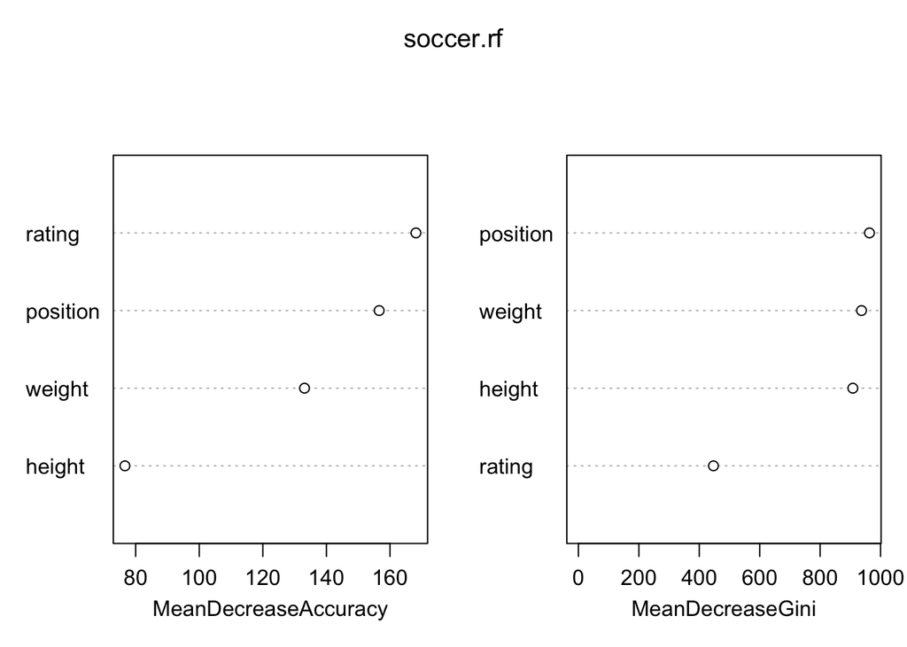

```r
varImpPlot(soccer.rf)
```

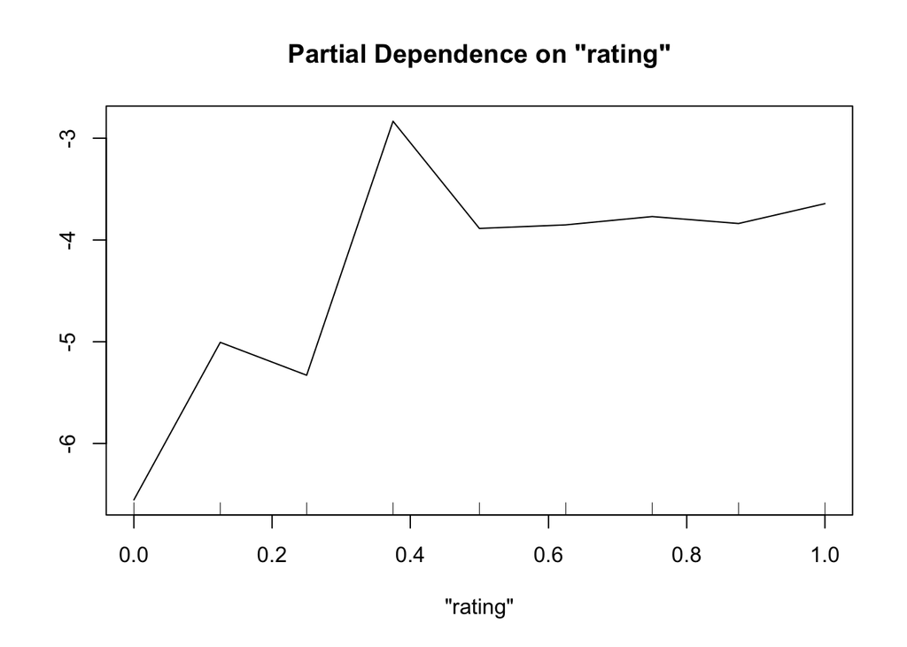

```r
partialPlot(soccer.rf, df.train[,-c(6,7,8,9)], x.var="rating", which.class = "1")
```

```r
#predicting for the test data
yhat.RF <- predict(soccer.rf, newdata=df.test, type="prob")
#Evaluate Performance characteristics for this model
library("ROCR")
rfs.pred<- prediction(yhat.RF[,2], df.test$card_result)
# misclassification rate
rfs.err <- performance(rfs.pred, measure = "err")
#AUC
rfs.AUC <- as.numeric(performance(rfs.pred, "auc")@y.values)
rfs.AUC
```

```
## [1] 0.609459
```

### **********************************************************************

### References:

- https://osf.io/gvm2z/wiki/home/
- http://www.nature.com/news/crowdsourced-research-many-hands-make-tight-work-1.18508